# Homework #4

**See Canvas for HW #4 assignment due date**. Complete all of the following problems. Ideally, the theoretical problems should be answered in a Markdown cell directly underneath the question. If you don't know LaTex/Markdown, you may submit separate handwritten solutions to the theoretical problems, but please see the [class scanning policy](https://docs.google.com/document/d/17y5ksolrn2rEuXYBv_3HeZhkPbYwt48UojNT1OvcB_w/edit?usp=sharing). Please do not turn in messy work. Computational problems should be completed in this notebook (using the R kernel). Computational questions may require code, plots, analysis, interpretation, etc. Working in small groups is allowed, but it is important that you make an effort to master the material and hand in your own work.

## A.1 The median of the exponential distribution

- In class, we defined the mean of a random variable $X$ with probability density function $f(x)$ to be $E(X) = \int^{\infty}_{-\infty}xf(x) dx$.
- We also defined the median of a random variable $X$ with probability density function $f(x)$ to be the value $m$ such that $P(X \le m) = 0.5$.

The exponential distribution has a density function $$f(x) = \lambda e^{-\lambda x},$$ for $x \ge 0$, where $\lambda > 0$ is the rate parameter. We showed in class that if $X \sim Exp(\lambda)$, then $E(X) = \frac{1}{\lambda}$.

**A.1(a) [5 points] Let $\lambda = 1$. Show that the median of $X \sim Exp(1)$ is $\log(2)$.**

Median of r.v $X$ is $P(X \leq m) = 0.5$

Let $\lambda = 1$: $$ P(X \leq m) = \int^m_0 e^{-x} dx = 0.5$$ $$-e^{-x} \Biggr|^m_0 = 0.5$$ $$-e^{-m} = -0.5$$ $$e^{-m}= 0.5$$ $$-m = log(\frac{1}{2})$$ $$-m = log(1) - log(2)$$ $$m = log(2)$$

**A.1(b) [5 points] Let $\lambda = 2$. Show that the median of $X \sim Exp(2)$ is $\frac{\log(2)}{2}$.**

$$X \sim Exp(2) \Rightarrow P(X \leq m) = \int^m_0 2e^{-2x}dx = 0.5$$$$-e^{-2x} \Biggr|^m_0 = 0.5$$$$-e^{-2m} = -0.5$$$$e^{-2m} = 0.5$$$$-2m = log(\frac{1}{2})$$$$ m = \frac{log(2)}{2}$$

**A.1(c) [7 points] Argue that for $X \sim Exp(\lambda)$, the median is given by $\frac{\log(2)}{\lambda}$**

$$ X \sim Exp(\lambda) \Rightarrow P(X \leq m) = \int^m_0 = \lambda e^{-\lambda x}dx$$$$ -e^{-\lambda x} = 0.5 $$$$ m = \frac{log(2)}{\lambda}$$

The median is given by $m = \frac{log(2)}{\lambda}$ because as we evauluate $P(X \leq m) = 0.5$, the integral will always estimate to $log(2)$ times some constant. If the the value $m$ was other than $ P(X \leq m)= C$ the intragral would equal some other value. However, becuase our median is $0.5$ we will alwasy evaulate to $\frac{log(2)}{\lambda}$

## A.2 Expected values and bets

**Let $X =$ the outcome when a fair die is rolled once. Suppose that, before the die is rolled, you are offered a choice:**

*Option 1: a guarantee of 1/4 dollars (whatever the outcome of the roll)*

*Option 2: h(X) = 1/X dollars. Which option would you prefer?*

**Justify your answer.**

I would prefer option 2 becuase you have more of a probability of rolling a value $x \leq \frac{1}{4}$. Since there a six numbers on a die the probability for rolling a value $x > 4$ is $$P(X) = 1/6, x \in \{1,2,...,6\}$$ $$P(X>4)= 1 - P(X\leq4) = 33\%$$ Which in turn is the amount of money you will recieve less than $\frac{1}{4}$

Nevertheless, the probability of rolling a die $x \leq 4$ is $$P(X \leq 4) = \sum^4_1 \frac{1}{6} = 66\%$$ Therefore you have a higher chance rolling $x \leq 4$ than $x > 4$.

Option one guarantees you $\frac{1}{4}$ of a dollar no matter what the roll. Since I know the chances of rolling lower than a 4 is reasonably good I would take the risk.

## A.3 More fraud

Recall the distribution from a previous homework: $X =$ the leading digit of a randomly selected number from a large accounting ledger. The pmf was defined by: $$ P(X=x) = f(x) = log_{10}\Big(\frac{x+1}{x}\Big), \ \ x=1,2,...,9. $$

**Find $E(X)$.**

(The extra code cell is if you'd like to verify/calculate it in R.)

$E(X) = \sum^9_1 xP(x) = \sum^9_1 x\bigg(log(\frac{x+1}{x})\bigg)$

```r
#YOUR CODE HERE
ex = 0

for (x in 1:9) {
    ex = ex + x*log10((x+1)/x)
}
ex
```

3.44023696712321

## A.4 Mixture distributions

Most of the distributions we've looked at so far have been unimodal, flat, or monotonically increasing/decreasing. Let's take a look at a class of distributions that are multimodal.

Let $X_1,...,X_n$ be continuous random variables with pdfs $f_{X_i}(x)$, $i = 1,...,n$. Define a *mixture distribution* to be a random variable $X$ with pdf

\begin{align*} f_X(x) = \sum^n_{i=1}\alpha_i f_{X_i}(x) \end{align*}

where $\alpha_i$ are nonnegative real numbers such that $\sum^n_{i=1}\alpha_1 = 1$.

**A.4(a) Show that $f_X(x)$ is a pdf.**

First we must show that $f_x(x) \geq 0, \forall x$

Well, we know that $\alpha_i \geq 0$ and $\sum^n_{i = 1} \alpha_i =1$. We also know that $f_{X_i}(x)$ are pdfs therefore $f_{X_i}(x) \geq 0$. Since $\alpha_i \geq 0$ and $f_{X_i}(x) \geq 0$ therefore $f_X(x) \geq 0, \forall x$.

Second, we want to show $\int^{\infty}_{-\infty}f_X(x)dx = 1$. So, $$\int^{\infty}_{-\infty} \sum^n_{i=1}\alpha_i f_{X_i}(x)dx$$ $$\sum^n_{i=1}\int^{\infty}_{-\infty}\alpha_i f_{X_i}(x)dx$$ $$\sum^n_{i=1}\alpha_i \int^{\infty}_{-\infty} f_{X_i}(x)dx$$ Since $f_{X_i}(x)$ are pdf's then we know that the integral of pdfs are 1. $$\sum^n_{i=1}\alpha_i(1)$$ Additionally, $\sum^n_{i=1}\alpha_i = 1$, so $$\int^{\infty}_{-\infty}f_X(x)dx = 1$$

**A.4(b) Find the expected value of $X$.**

$$E(X) = \int^{\infty}_{\infty}xf_X(x)dx$$$$ = \int^{\infty}_{-\infty} x \sum^n_{i=1}\alpha_i f_{X_i}(x)dx$$$$ = \sum^n_{i=1}\alpha_i\int^{\infty}_{-\infty} x f_{X_i}(x)dx$$$$ = \sum^n_{i=1}\alpha_i E(X_i)$$

**A.4(b) Show that $Var(X) = \sum^n_{i=1}\alpha_i\left(\sigma^2_i + \mu_i^2 \right) - \mu^2$, where $\sigma^2_i = Var(X_i)$ and $\mu_i = E(X_i)$.**

HINT: Use the fact that, for a random variable $Y$, $Var(Y) = E(Y^2) - [E(Y)]^2$. It might be helpful to rearrange this equation at some point!

First look at: $$E(X) = \sum^n_{i=1}\alpha_i E(X_i)$$ We can also rearrange the hint for $Var(X_i)$: $$E(X^2_i) = Var(X_i) + [E(X_i)]^2$$ Additionally we know that: $$Var(X) = E(X^2) - [E(X)]^2$$

So plugging in $E(X^2)$ from what we found in $A.4(b)$: $$E(X^2) = \sum^n_{i=1}\alpha_i E(X_i^2)$$

And since we know what $E(X_i^2)$: $$Var(X) = \sum^n_{i=1}\alpha_i E(X_i^2) - \mu^2$$ $$Var(X) = \sum^n_{i=1}\alpha_i (\sigma_i^2 + \mu^2_i) - u^2$$

# B Computational problems

## B.1 Monte Carlo estimation

One really cool (and useful!) application of random variables is approximating integrals/the area under a curve. Consider $f(x) = sin(x)$ on the interval $0 \le x \le \pi$. Let's use uniform random variables to approximate the area under $f(x)$ on this interval. Note that this general idea is used often to solve really important but hard integrals!

**B.1(a) [6 points] By hand, and using the ${\tt integrate()}$ function in R, calculate the true area under $f(x)$.**

$$\int^\pi_0 sin(x) = -cos(x)\Big|^\pi_0 = 1 + 1 = 2$$

```r
integrate(sin, 0, pi)
```

```
2 with absolute error < 2.2e-14
```

**B.1(b) [3 points] Generate $n = 5,000$ uniform random $(x,y)$ coordinates in the rectangle $x \in [0,\pi], \, y \in [0,1]$.**

```r
n = 5000
x = runif(n, 0, pi)
y = runif(n, 0, 1)
```

**B.1(c) [6 points] Calculate the proportion of points from B.1(b) that fall below $f(x)$ and use this proportion to approximate the area under $f(x)$.**

0.6366

1.99993788327526

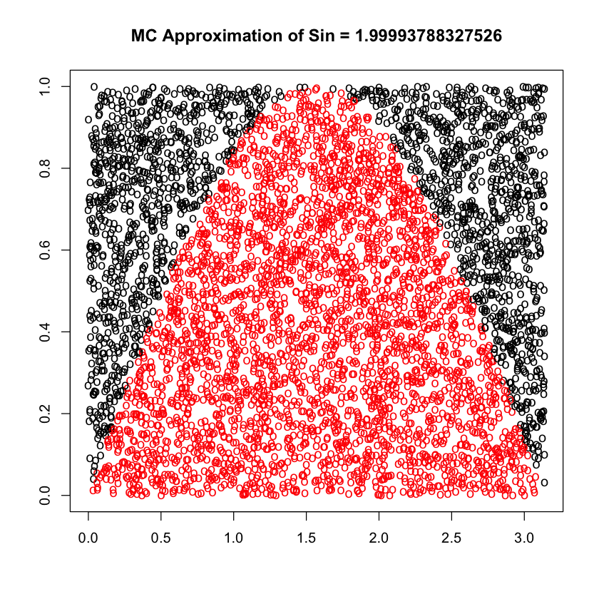

```r
under_sin = y <= sin(x)
sum(under_sin)/n
apprx = (sum(under_sin)/n)*pi
apprx
plot(x,y,pch='o',col=ifelse(under_sin,"red","black"), xlab=''
     ,ylab='', main=paste("MC Approximation of Sin =",apprx))
```

**B.1(d) Find the absolute difference between our approximation and the true area calculated in B.1(a). How can we make this error smaller?**

```r
diff = abs(2 - apprx)
diff
```

6.21167247374377e-05

We can make the error smaller by calculating more uniform random points.

## B.2

For this problem, let's assume that the probability of an event $E$, $P(E)$, means something like "the degree to which you believe $E$".

**B.2(a) In the same window, plot four different beta distributions (pdf):**

1. beta(1,1)
2. beta(0.5,0.5)
3. beta(5,5)
4. beta(1,5)

**What is another name for $1$?**

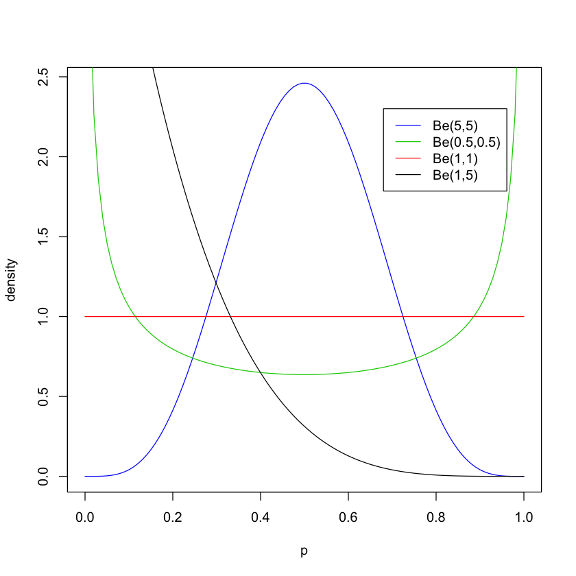

```r
p = seq(0,1, length=100)
plot(p, dbeta(p, 5, 5), ylab="density", type ="l", col=4)
lines(p, dbeta(p, 0.5, 0.5), type ="l", col=3)
lines(p, dbeta(p, 1, 1), col=2)
lines(p, dbeta(p, 1, 5), col=1)
legend(0.68,2.3, c("Be(5,5)","Be(0.5,0.5)","Be(1,1)", "Be(1,5)"),lty=c(1,1,1,1),col=c(4,3,2,1))
```

Another name for beta(1,1) is a equal probability for all values

**B.2(b) Now, suppose your friend has a coin whose probabilities are unknown to you. Since the beta distribution has support $[0,1]$, it is well-suited to model your beliefs about the probability of heads. Match the following descriptions with the beta distributions from the previous part.**

i. I am pretty confident that this is a two-headed or two-tailed coin.

ii. I have no idea what the probability of heads is.

iii. I believe that the probability of heads is low.

iv. I believe that the coin is close to fair.

i. Beta distribution of beta(0.5,0.5)

ii. Beta distribution of beta(1,1)

iii. Beta distribution of beta(1,5)

iv. Beta distribution of beta(5,5)

## B.3 Mixture distributions

Most of the distributions we've looked at so far have been unimodal, flat, or monotonically increasing/decreasing. Let's take a look at a class of distributions that are multimodal.

Let $X_1,...,X_n$ be continuous random variables with pdfs $f_{X_i}(x)$, $i = 1,...,n$. Define a *mixture distribution* to be a random variable $X$ with pdf

\begin{align*} f_X(x) = \sum^n_{i=1}\alpha_i f_{X_i}(x) \end{align*}

where $\alpha_i$ are nonnegative real numbers such that $\sum^n_{i=1}\alpha_1 = 1$.

**B.3(a) For this question, let's create a specific mixture distribution and plot the pdf in R.**

1. First, create a grid of `n = 100` `x` values evenly spaced between `0` and `15`.
2. Construct an `alpha` vector with entries `1/5`, `2/5`, and `2/5`.
3. At each value of `x`, calculate the following:
   - the pdf of an exponential with rate parameter `1`.
   - the pdf of a normal distribution with mean `5` and standard deviation `1` (we haven't officially defined the normal distribution yet, but you can construct its pdf with `dnorm(x, mean, sd)`.
   - the pdf of a normal distribution with mean `10` and standard deviation `2`
4. Construct the pdf of the mixture random variable using `alpha` and pdfs from 3.
5. Plot the pdf of the mixture distribution. What do you notice about it's shape? How does the shape relate to the shape of the original distributions?

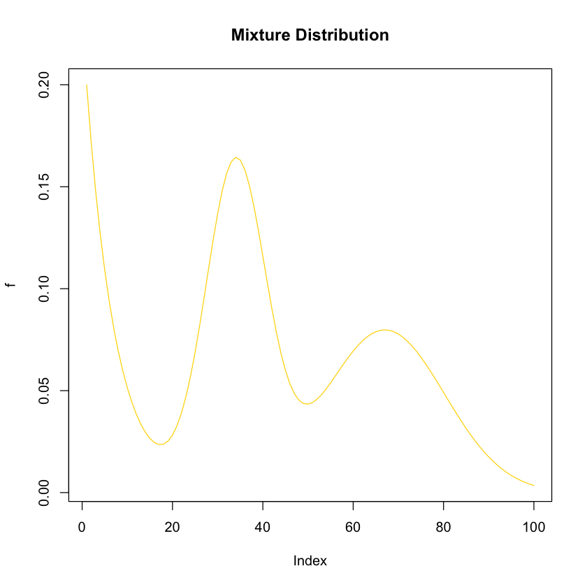

```r
n = 100
x = seq(0,15, length=n)
alpha = c(1/5,2/5,2/5)
#lambda = 1
#Matrix to store exponential of x
exp = matrix(data = NA, nrow = n, ncol = 1)

#Matrix to store normal dist. of mean 5 and sd 1
nd = matrix(data = NA, nrow = n, ncol = 1)

#Matrix to store normal dist. of mean 10 and sd 2
nd2 = matrix(data = NA, nrow = n, ncol = 1)

#
f = matrix(data = NA, nrow = )
for (i in 1:n){
    #PDF of exponential for each x
    exp[i] = dexp(x[i],1)
    #PDF of Normal Dist. mean 5, sd 1
    nd[i] = dnorm(x[i], 5, 1)
    #PDF of Normal Dist. mean 10, sd 2
    nd2[i] = dnorm(x[i], 10, 2)
}
pdf_1 = alpha[1]*exp
pdf_2 = alpha[2]*nd
pdf_3 = alpha[3]*nd2
f = pdf_1 + pdf_2 + pdf_3
plot(f,type ="l", col='gold', main="Mixture Distribution")
```

**B.3(b) In this part, generate $m = 50,000$ random numbers from the mixture distribution that we worked with in B.3(a), and store those numbers in a vector `v`. The algorithm below should help!**

1. Generate a single random number from the continuous uniform distribution $U(0,1)$. Call this number `u`.
2. Use `u` to select among the three distributions from B.3(a) (i.e., $Exp(1)$, $N(5,1)$ or $N(10,2)$). For example, generate a random number from $Exp(1)$ if `u < 1/5`.
3. Repeat this process `m = 50,000` times.

Then, create a histogram of `v`, and set `breaks = 25`. What do you notice about the distribution?

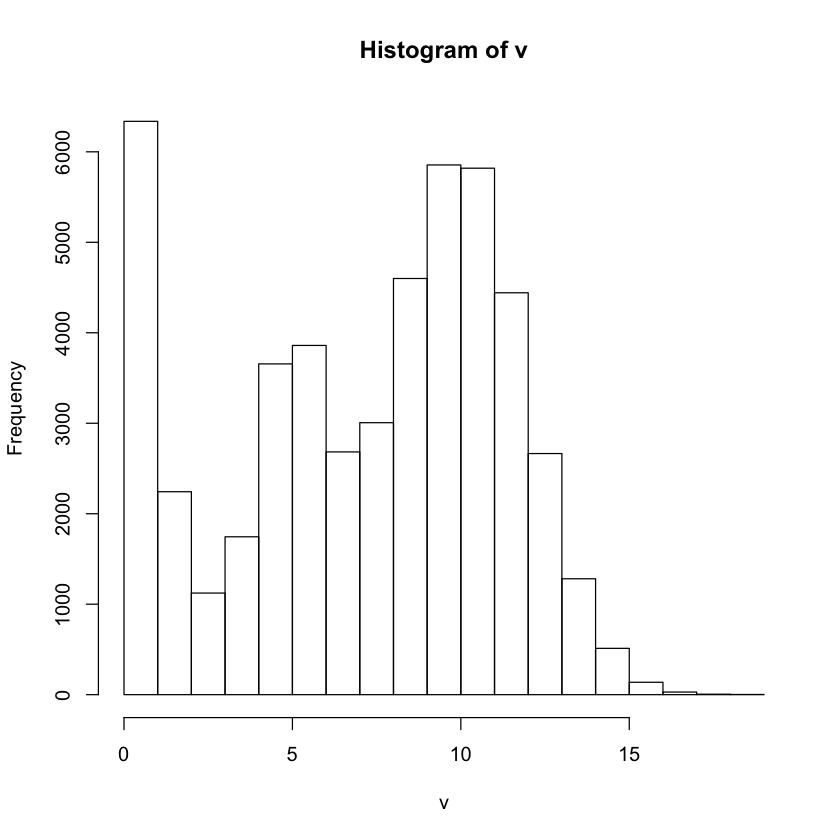

```r
m = 50000
single = 1
u = 0
v = matrix(data = NA, nrow = m, ncol = 1)
for (i in 1:m){
    u = runif(single,0,1)
    if(u < 1/5){
        v[i] = rexp(1)
    }else if(1/5 < u && u < 2/5){
        v[i] = rnorm(1,5,1)
    }else {
        v[i] = rnorm(1,10,2)
    }
}
hist(v, breaks = 25)
```

**B.3(c) Compute the theoretical mean and variance for this mixture, i.e., $E(X)$ and $Var(X)$ from A.4. Then, compare those values to the sample mean and variance of `v`. What do you notice?**

```r
# First method of computing the theoretical mean and variance by integrating
#E(X)
expected_x = function(x){
    f = (alpha[1]*dexp(x,1) + alpha[2]*dnorm(x,5,1) + alpha[3]*dnorm(x,10,2))
    x*f
}

#E(X^2)
expected_x2 = function(x){
    f = (alpha[1]*dexp(x,1) + alpha[2]*dnorm(x,5,1) + alpha[3]*dnorm(x, 10, 2))
    x^2*f
}

#E(X)
exp_x = alpha[1]*1 + alpha[2]*5 + alpha[3]*10


integrate(expected_x, -Inf, Inf)
integrate(expected_x2, -Inf, Inf)
# Var(X) = E(X^2) - E(X)^2 = 52.4 - 6.2^2 from the values returned by the integrate
var_x = 52.4 - 6.2**2

cat("E(X): ", 6.2, '\n')
cat("Var(X): " ,var_x, '\n')

cat("sample mean: ", mean(v), '\n')
cat("samples variance: ", var(v))
```

```
6.2 with absolute error < 0.00039
```

```
52.4 with absolute error < 0.0017
```

```
E(X):  6.2
Var(X):  13.96
sample mean:  7.198983
samples variance:  16.04964
```

```r
# Second method of inputing the variables given.
#E(X)
exp_x = alpha[1]*1 + alpha[2]*5 + alpha[3]*10

sig2_mu2 = alpha[1]*(1 + 1) + alpha[2]*(1 + 25) + alpha[3]*(4 + 100)
variance_x = sig2_mu2 - exp_x^2


cat("E(X): ", exp_x, '\n')
cat("Var(X): " ,variance_x, '\n')

cat("sample mean: ", mean(v), '\n')
cat("samples variance: ", var(v))
```

```
E(X):  6.2
Var(X):  13.96
sample mean:  7.198983
samples variance:  16.04964
```